# Capstone: Logistic Regression

Andrew Knittle

Generated on 2021-07-31

# Exploring the Data

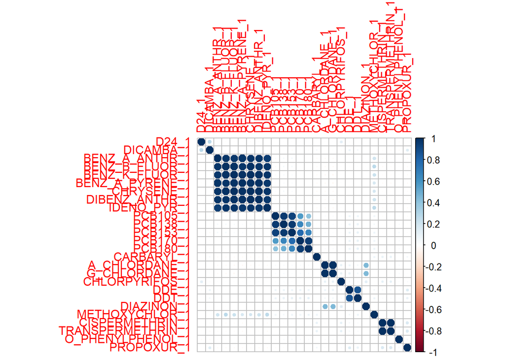

Correlation Matrix

As we can see there are many variables that are highly correlated. The goal now is to find what variables we need and which we can throw out. We will break the variables into groups reflecting the output from the correlation graph.

# Finding the Right Variables

Call: glm(formula = CASESTAT ~ BENZ_A_ANTHR_1, family = “binomial”, data = train_DustData)

Deviance Residuals: Min 1Q Median 3Q Max  
-1.294 -1.293 1.065 1.066 1.066

Coefficients: Estimate Std. Error z value Pr(>|z|) (Intercept) 0.2670105 0.2321205 1.150 0.250 BENZ_A_ANTHR_1 0.0009195 0.1018026 0.009 0.993

(Dispersion parameter for binomial family taken to be 1)

```
Null deviance: 1453.2  on 1061  degrees of freedom
```

Residual deviance: 1453.2 on 1060 degrees of freedom AIC: 1457.2

Number of Fisher Scoring iterations: 4

Call: glm(formula = CASESTAT ~ BENZ_B_FLUOR_1, family = “binomial”, data = train_DustData)

Deviance Residuals: Min 1Q Median 3Q Max  
-1.317 -1.294 1.060 1.065 1.087

Coefficients: Estimate Std. Error z value Pr(>|z|) (Intercept) 0.33131 0.26203 1.264 0.206 BENZ_B_FLUOR_1 -0.02464 0.10070 -0.245 0.807

(Dispersion parameter for binomial family taken to be 1)

```
Null deviance: 1453.2  on 1061  degrees of freedom
```

Residual deviance: 1453.1 on 1060 degrees of freedom AIC: 1457.1

Number of Fisher Scoring iterations: 4

Call: glm(formula = CASESTAT ~ BENZ_K_FLUOR_1, family = “binomial”, data = train_DustData)

Deviance Residuals: Min 1Q Median 3Q Max  
-1.334 -1.290 1.053 1.068 1.096

Coefficients: Estimate Std. Error z value Pr(>|z|) (Intercept) 0.18018 0.21576 0.835 0.404 BENZ_K_FLUOR_1 0.04292 0.09988 0.430 0.667

(Dispersion parameter for binomial family taken to be 1)

```
Null deviance: 1453.2  on 1061  degrees of freedom
```

Residual deviance: 1453.0 on 1060 degrees of freedom AIC: 1457

Number of Fisher Scoring iterations: 4

Call: glm(formula = CASESTAT ~ BENZ_A_PYRENE_1, family = “binomial”, data = train_DustData)

Deviance Residuals: Min 1Q Median 3Q Max  
-1.350 -1.287 1.048 1.069 1.104

Coefficients: Estimate Std. Error z value Pr(>|z|) (Intercept) 0.13967 0.22630 0.617 0.537 BENZ_A_PYRENE_1 0.05766 0.09709 0.594 0.553

(Dispersion parameter for binomial family taken to be 1)

```
Null deviance: 1453.2  on 1061  degrees of freedom
```

Residual deviance: 1452.8 on 1060 degrees of freedom AIC: 1456.8

Number of Fisher Scoring iterations: 4

Call: glm(formula = CASESTAT ~ CHRYSENE_1, family = “binomial”, data = train_DustData)

Deviance Residuals: Min 1Q Median 3Q Max  
-1.322 -1.293 1.052 1.065 1.112

Coefficients: Estimate Std. Error z value Pr(>|z|) (Intercept) 0.41642 0.28796 1.446 0.148 CHRYSENE_1 -0.05876 0.11206 -0.524 0.600

(Dispersion parameter for binomial family taken to be 1)

```
Null deviance: 1453.2  on 1061  degrees of freedom
```

Residual deviance: 1452.9 on 1060 degrees of freedom AIC: 1456.9

Number of Fisher Scoring iterations: 4

Call: glm(formula = CASESTAT ~ DIBENZ_ANTHR_1, family = “binomial”, data = train_DustData)

Deviance Residuals: Min 1Q Median 3Q Max  
-1.354 -1.290 1.047 1.068 1.105

Coefficients: Estimate Std. Error z value Pr(>|z|) (Intercept) 0.16763 0.16511 1.015 0.310 DIBENZ_ANTHR_1 0.06350 0.09595 0.662 0.508

(Dispersion parameter for binomial family taken to be 1)

```
Null deviance: 1453.2  on 1061  degrees of freedom
```

Residual deviance: 1452.8 on 1060 degrees of freedom AIC: 1456.8

Number of Fisher Scoring iterations: 4

Call: glm(formula = CASESTAT ~ IDENO_PYR_1, family = “binomial”, data = train_DustData)

Deviance Residuals: Min 1Q Median 3Q Max  
-1.326 -1.294 1.056 1.065 1.098

Coefficients: Estimate Std. Error z value Pr(>|z|) (Intercept) 0.35560 0.23015 1.545 0.122 IDENO_PYR_1 -0.03787 0.09692 -0.391 0.696

(Dispersion parameter for binomial family taken to be 1)

```
Null deviance: 1453.2  on 1061  degrees of freedom
```

Residual deviance: 1453.0 on 1060 degrees of freedom AIC: 1457

Number of Fisher Scoring iterations: 4

Call: glm(formula = CASESTAT ~ PCB105_1, family = “binomial”, data = train_DustData)

Deviance Residuals: Min 1Q Median 3Q Max  
-1.434 -1.280 1.026 1.075 1.110

Coefficients: Estimate Std. Error z value Pr(>|z|) (Intercept) 0.1584 0.1070 1.480 0.139 PCB105_1 0.1377 0.1091 1.262 0.207

(Dispersion parameter for binomial family taken to be 1)

```
Null deviance: 1453.2  on 1061  degrees of freedom
```

Residual deviance: 1451.6 on 1060 degrees of freedom AIC: 1455.6

Number of Fisher Scoring iterations: 4

Call: glm(formula = CASESTAT ~ PCB138_1, family = “binomial”, data = train_DustData)

Deviance Residuals: Min 1Q Median 3Q Max  
-1.365 -1.288 1.045 1.069 1.093

Coefficients: Estimate Std. Error z value Pr(>|z|)  
(Intercept) 0.20169 0.11904 1.694 0.0902 . PCB138_1 0.06378 0.09646 0.661 0.5085  
— Signif. codes: 0 ‘**’ 0.001 ’**’ 0.01 ’’ 0.05 ‘.’ 0.1 ’ ’ 1

(Dispersion parameter for binomial family taken to be 1)

```
Null deviance: 1453.2  on 1061  degrees of freedom
```

Residual deviance: 1452.8 on 1060 degrees of freedom AIC: 1456.8

Number of Fisher Scoring iterations: 4

Call: glm(formula = CASESTAT ~ PCB153_1, family = “binomial”, data = train_DustData)

Deviance Residuals: Min 1Q Median 3Q Max  
-1.413 -1.283 1.031 1.071 1.117

Coefficients: Estimate Std. Error z value Pr(>|z|) (Intercept) 0.14019 0.12590 1.113 0.265 PCB153_1 0.11347 0.09681 1.172 0.241

(Dispersion parameter for binomial family taken to be 1)

```
Null deviance: 1453.2  on 1061  degrees of freedom
```

Residual deviance: 1451.8 on 1060 degrees of freedom AIC: 1455.8

Number of Fisher Scoring iterations: 4

Call: glm(formula = CASESTAT ~ PCB170_1, family = “binomial”, data = train_DustData)

Deviance Residuals: Min 1Q Median 3Q Max  
-1.432 -1.274 1.018 1.079 1.103

Coefficients: Estimate Std. Error z value Pr(>|z|)  
(Intercept) 0.17626 0.09202 1.915 0.0554 . PCB170_1 0.15235 0.11239 1.356 0.1752  
— Signif. codes: 0 ‘**’ 0.001 ’**’ 0.01 ’’ 0.05 ‘.’ 0.1 ’ ’ 1

(Dispersion parameter for binomial family taken to be 1)

```
Null deviance: 1453.2  on 1061  degrees of freedom
```

Residual deviance: 1451.3 on 1060 degrees of freedom AIC: 1455.3

Number of Fisher Scoring iterations: 4

Call: glm(formula = CASESTAT ~ PCB180_1, family = “binomial”, data = train_DustData)

Deviance Residuals: Min 1Q Median 3Q Max  
-1.479 -1.273 1.004 1.075 1.141

Coefficients: Estimate Std. Error z value Pr(>|z|)  
(Intercept) 0.08301 0.11678 0.711 0.4772  
PCB180_1 0.20001 0.10699 1.869 0.0616 . — Signif. codes: 0 ‘**’ 0.001 ’**’ 0.01 ’’ 0.05 ‘.’ 0.1 ’ ’ 1

(Dispersion parameter for binomial family taken to be 1)

```
Null deviance: 1453.2  on 1061  degrees of freedom
```

Residual deviance: 1449.7 on 1060 degrees of freedom AIC: 1453.7

Number of Fisher Scoring iterations: 4

Call: glm(formula = CASESTAT ~ A_CHLORDANE_1, family = “binomial”, data = train_DustData)

Deviance Residuals: Min 1Q Median 3Q Max  
-1.392 -1.283 1.032 1.072 1.107

Coefficients: Estimate Std. Error z value Pr(>|z|) (Intercept) 0.16662 0.11750 1.418 0.156 A_CHLORDANE_1 0.08629 0.08436 1.023 0.306

(Dispersion parameter for binomial family taken to be 1)

```
Null deviance: 1453.2  on 1061  degrees of freedom
```

Residual deviance: 1452.2 on 1060 degrees of freedom AIC: 1456.2

Number of Fisher Scoring iterations: 4

Call: glm(formula = CASESTAT ~ G_CHLORDANE_1, family = “binomial”, data = train_DustData)

Deviance Residuals: Min 1Q Median 3Q Max  
-1.375 -1.287 1.036 1.071 1.104

Coefficients: Estimate Std. Error z value Pr(>|z|) (Intercept) 0.17464 0.12395 1.409 0.159 G_CHLORDANE_1 0.07094 0.08086 0.877 0.380

(Dispersion parameter for binomial family taken to be 1)

```
Null deviance: 1453.2  on 1061  degrees of freedom
```

Residual deviance: 1452.4 on 1060 degrees of freedom AIC: 1456.4

Number of Fisher Scoring iterations: 4

Call: glm(formula = CASESTAT ~ DDE_1, family = “binomial”, data = train_DustData)

Deviance Residuals: Min 1Q Median 3Q Max  
-1.470 -1.278 1.011 1.070 1.167

Coefficients: Estimate Std. Error z value Pr(>|z|)  
(Intercept) -0.01218 0.16849 -0.072 0.9424  
DDE_1 0.21330 0.11920 1.789 0.0735 . — Signif. codes: 0 ‘**’ 0.001 ’**’ 0.01 ’’ 0.05 ‘.’ 0.1 ’ ’ 1

(Dispersion parameter for binomial family taken to be 1)

```
Null deviance: 1453.2  on 1061  degrees of freedom
```

Residual deviance: 1450.0 on 1060 degrees of freedom AIC: 1454

Number of Fisher Scoring iterations: 4

Call: glm(formula = CASESTAT ~ DDT_1, family = “binomial”, data = train_DustData)

Deviance Residuals: Min 1Q Median 3Q Max  
-1.314 -1.291 1.054 1.068 1.093

Coefficients: Estimate Std. Error z value Pr(>|z|)  
(Intercept) 0.31871 0.15761 2.022 0.0432 * DDT_1 -0.02669 0.07782 -0.343 0.7316  
— Signif. codes: 0 ‘**’ 0.001 ’**’ 0.01 ’’ 0.05 ‘.’ 0.1 ’ ’ 1

(Dispersion parameter for binomial family taken to be 1)

```
Null deviance: 1453.2  on 1061  degrees of freedom
```

Residual deviance: 1453.1 on 1060 degrees of freedom AIC: 1457.1

Number of Fisher Scoring iterations: 4

Call: glm(formula = CASESTAT ~ CISPERMETHRIN_1, family = “binomial”, data = train_DustData)

Deviance Residuals: Min 1Q Median 3Q Max  
-1.307 -1.292 1.059 1.066 1.080

Coefficients: Estimate Std. Error z value Pr(>|z|)  
(Intercept) 0.30049 0.15770 1.905 0.0567 . CISPERMETHRIN_1 -0.01238 0.05706 -0.217 0.8282  
— Signif. codes: 0 ‘**’ 0.001 ’**’ 0.01 ’’ 0.05 ‘.’ 0.1 ’ ’ 1

(Dispersion parameter for binomial family taken to be 1)

```
Null deviance: 1453.2  on 1061  degrees of freedom
```

Residual deviance: 1453.2 on 1060 degrees of freedom AIC: 1457.2

Number of Fisher Scoring iterations: 4

Call: glm(formula = CASESTAT ~ TRANSPERMETHRIN_1, family = “binomial”, data = train_DustData)

Deviance Residuals: Min 1Q Median 3Q Max  
-1.323 -1.290 1.048 1.068 1.094

Coefficients: Estimate Std. Error z value Pr(>|z|)  
(Intercept) 0.33601 0.15374 2.186 0.0288 * TRANSPERMETHRIN_1 -0.02462 0.05167 -0.476 0.6338  
— Signif. codes: 0 ‘**’ 0.001 ’**’ 0.01 ’’ 0.05 ‘.’ 0.1 ’ ’ 1

(Dispersion parameter for binomial family taken to be 1)

```
Null deviance: 1453.2  on 1061  degrees of freedom
```

Residual deviance: 1453.0 on 1060 degrees of freedom AIC: 1457

Number of Fisher Scoring iterations: 4

# Building Models

## Stepwise Selection

This model will be built using stepwise selection, using AIC as a criteria.

Call: glm(formula = CASESTAT ~ D24_1 + BENZ_K_FLUOR_1 + BENZ_A_PYRENE_1 + CHRYSENE_1 + IDENO_PYR_1 + PCB180_1 + DDE_1 + DDT_1 + DIAZINON_1 + METHOXYCHLOR_1, family = “binomial”, data = train_DustData)

Deviance Residuals: Min 1Q Median 3Q Max  
-1.7761 -1.2143 0.8479 1.0580 1.7439

Coefficients: Estimate Std. Error z value Pr(>|z|)  
(Intercept) 1.45849 0.41661 3.501 0.000464 *D24_1 -0.18747 0.08143 -2.302 0.021322*  
BENZ_K_FLUOR_1 0.83259 0.38053 2.188 0.028673 *  
BENZ_A_PYRENE_1 1.35776 0.41031 3.309 0.000936 *CHRYSENE_1 -1.19248 0.42083 -2.834 0.004602 **IDENO_PYR_1 -1.13623 0.40132 -2.831 0.004637** PCB180_1 0.28079 0.12397 2.265 0.023515*  
DDE_1 0.63018 0.19814 3.181 0.001470 ** DDT_1 -0.26870 0.12791 -2.101 0.035666 *  
DIAZINON_1 -0.19997 0.07621 -2.624 0.008697 ** METHOXYCHLOR_1 -0.12636 0.08607 -1.468 0.142074  
— Signif. codes: 0 ‘**’ 0.001 ’**’ 0.01 ’’ 0.05 ‘.’ 0.1 ’ ’ 1

(Dispersion parameter for binomial family taken to be 1)

```
Null deviance: 1453.2  on 1061  degrees of freedom
```

Residual deviance: 1404.4 on 1051 degrees of freedom AIC: 1426.4

Number of Fisher Scoring iterations: 4

## Using Hand Picked Variables

Using the variables selected from before this is the current model

Call: glm(formula = CASESTAT ~ CHRYSENE_1 + PCB105_1 + PCB180_1 + A_CHLORDANE_1 + DDE_1 + TRANSPERMETHRIN_1, family = “binomial”, data = train_DustData)

Deviance Residuals: Min 1Q Median 3Q Max  
-1.5328 -1.2813 0.9857 1.0674 1.2512

Coefficients: Estimate Std. Error z value Pr(>|z|) (Intercept) 0.28152 0.35281 0.798 0.425 CHRYSENE_1 -0.11704 0.11519 -1.016 0.310 PCB105_1 -0.01257 0.14728 -0.085 0.932 PCB180_1 0.16390 0.14638 1.120 0.263 A_CHLORDANE_1 0.01391 0.09546 0.146 0.884 DDE_1 0.16574 0.14172 1.170 0.242 TRANSPERMETHRIN_1 -0.03541 0.05278 -0.671 0.502

(Dispersion parameter for binomial family taken to be 1)

```
Null deviance: 1453.2  on 1061  degrees of freedom
```

Residual deviance: 1446.9 on 1055 degrees of freedom AIC: 1460.9

Number of Fisher Scoring iterations: 4

# Comparing Models

## Handselected Model

[1] 0.5715631 [[1]] Observed NO Observed YES Predicted NO 27 22 Predicted YES 433 580

[[2]] Error Rate False Positive Rate (Fall-Out) False Negative Rate (Miss Rate) 1 0.4284369 0.9413043 0.03654485 True Positive Rate (Sensitivity) True Negative Rate (Specificity) 1 0.9634551 0.05869565

| Model | Error_Rate |
| --- | --- |
| Logistic Model | 0.4397363 |

## Stepwise Model

[[1]] Observed NO Observed YES Predicted NO 156 103 Predicted YES 304 499

[[2]] Error Rate False Positive Rate (Fall-Out) False Negative Rate (Miss Rate) 1 0.3832392 0.6608696 0.1710963 True Positive Rate (Sensitivity) True Negative Rate (Specificity) 1 0.8289037 0.3391304

| Model | Error_Rate |
| --- | --- |
| Logistic Model | 0.4086629 |

# Conclusion

The Stepwise Model performed best compare to “By Hand” model in terms of error rate for the test set using 10-Fold Cross Validation.

## Method

Logistic Regression was chosen because of the binary dependent variable and the simplicity of implementing it. Logistic Regression gives us the probability that someone will likely contract cancer when introduced to the chemicals in the model, and based on that probability we can classify a person developing cancer or not.